# Project: Investigate the European Soccer Dataset

- Introduction
- Data Wrangling
- Exploratory Data Analysis
- Conclusions

## Introduction

> The dataset is a European Soccer Database from Kaggle. it contains match information of 10 different European leagues starting from 2008 to 2016. The database also carries information on team and player attributes. In this analysis, I will focus on four countries: England, Spain, Germany, and Italy.

> This analysis will answer the following questions:

> **1. What teams have improved the most over the time period?**  
> **2. What team attributes do lead to the most victories?**  
> **3. Does older player has higher overall rating than younger player?**

```python
# Import packages

import pandas as pd
import numpy as np
import datetime as dt
import matplotlib.pyplot as plt
% matplotlib inline
```

# Data Wrangling

### Exporting Dataset Using SQL Queries

> The datasets are exported to csv files using DB Browser for SQLite.

> For the "match_full" dataset, I join the Country table, Team table, and Matches table to show all the necessary information. The query is given below:

> > SELECT m.id, l.name AS league_name, c.name AS country_name,  
> > m.season, m.stage, m.date, ht.team_long_name AS home_team,  
> > at.team_long_name AS away_team, m.home_team_goal AS home_goal,  
> > m.away_team_goal AS team_goal  
> > JOIN League l ON m.league_id = l.id  
> > JOIN Country c ON m.country_id = c.id  
> > JOIN Team ht ON m.home_team_api_id = ht.team_api_id  
> > JOIN Team at ON m.away_team_api_id = at.team_api_id  
> > WHERE country_name IN ('England', 'Italy', 'Spain', 'Germany')  
> > GROUP BY 1  
> > ORDER BY 4, 5

> For the "team_attribute" dataset, I join the Team table and Team Attribute table using this query:

> > SELECT t.team_api_id, t.team_long_name AS team_name, ta.*  
> > FROM Team t  
> > JOIN Team_Attributes ta ON ta.team_api_id = t.team_api_id  
> > ORDER BY 1

> For the "player_attribute" dataset, I join the Player table with Player Attribute table using this query:

> > SELECT *  
> > FROM Player p  
> > JOIN Player_Attributes pa ON p.player_api_id = pa.player_api_id

### Import Pandas Dataframe from CSV Files

```python
## Dataframe for match

df_match = pd.read_csv('match_four_countries.csv')

df_match.head()
```

|  | id | league_name | country_name | season | stage | date | home_team | away_team | home_goal | team_goal |
| --- | --- | --- | --- | --- | --- | --- | --- | --- | --- | --- |
| 0 | 1729 | England Premier League | England | 2008/2009 | 1 | 2008-08-17 00:00:00 | Manchester United | Newcastle United | 1 | 1 |
| 1 | 1730 | England Premier League | England | 2008/2009 | 1 | 2008-08-16 00:00:00 | Arsenal | West Bromwich Albion | 1 | 0 |
| 2 | 1731 | England Premier League | England | 2008/2009 | 1 | 2008-08-16 00:00:00 | Sunderland | Liverpool | 0 | 1 |
| 3 | 1732 | England Premier League | England | 2008/2009 | 1 | 2008-08-16 00:00:00 | West Ham United | Wigan Athletic | 2 | 1 |
| 4 | 1733 | England Premier League | England | 2008/2009 | 1 | 2008-08-17 00:00:00 | Aston Villa | Manchester City | 4 | 2 |

```python
## Dataframe for team attribute

df_team_att = pd.read_csv('team_attribute.csv')

df_team_att.head()
```

|  | team_api_id | team_name | id | team_fifa_api_id | team_api_id.1 | date | buildUpPlaySpeed | buildUpPlaySpeedClass | buildUpPlayDribbling | buildUpPlayDribblingClass | ... | chanceCreationShooting | chanceCreationShootingClass | chanceCreationPositioningClass | defencePressure | defencePressureClass | defenceAggression | defenceAggressionClass | defenceTeamWidth | defenceTeamWidthClass | defenceDefenderLineClass |
| --- | --- | --- | --- | --- | --- | --- | --- | --- | --- | --- | --- | --- | --- | --- | --- | --- | --- | --- | --- | --- | --- |
| 0 | 1601 | Ruch Chorzów | 1113 | 874 | 1601 | 2010-02-22 00:00:00 | 30 | Slow | NaN | Little | ... | 70 | Lots | Organised | 65 | Medium | 60 | Press | 50 | Normal | Cover |
| 1 | 1601 | Ruch Chorzów | 1114 | 874 | 1601 | 2011-02-22 00:00:00 | 48 | Balanced | NaN | Little | ... | 51 | Normal | Organised | 46 | Medium | 48 | Press | 50 | Normal | Cover |
| 2 | 1601 | Ruch Chorzów | 1115 | 874 | 1601 | 2012-02-22 00:00:00 | 53 | Balanced | NaN | Little | ... | 50 | Normal | Organised | 43 | Medium | 44 | Press | 49 | Normal | Cover |
| 3 | 1601 | Ruch Chorzów | 1116 | 874 | 1601 | 2013-09-20 00:00:00 | 53 | Balanced | NaN | Little | ... | 50 | Normal | Organised | 43 | Medium | 44 | Press | 49 | Normal | Cover |
| 4 | 1601 | Ruch Chorzów | 1117 | 874 | 1601 | 2014-09-19 00:00:00 | 53 | Balanced | 48.0 | Normal | ... | 50 | Normal | Organised | 43 | Medium | 44 | Press | 49 | Normal | Cover |

5 rows × 27 columns

```python
## Dataframe for player attribute

df_player_att = pd.read_csv('player_attribute.csv')

df_player_att.head()
```

|  | id | player_api_id | player_name | player_fifa_api_id | birthday | height | weight | id.1 | player_fifa_api_id.1 | player_api_id.1 | ... | vision | penalties | marking | standing_tackle | sliding_tackle | gk_diving | gk_handling | gk_kicking | gk_positioning | gk_reflexes |
| --- | --- | --- | --- | --- | --- | --- | --- | --- | --- | --- | --- | --- | --- | --- | --- | --- | --- | --- | --- | --- | --- |
| 0 | 1 | 505942 | Aaron Appindangoye | 218353 | 1992-02-29 00:00:00 | 182.88 | 187 | 1 | 218353 | 505942 | ... | 54.0 | 48.0 | 65.0 | 69.0 | 69.0 | 6.0 | 11.0 | 10.0 | 8.0 | 8.0 |
| 1 | 1 | 505942 | Aaron Appindangoye | 218353 | 1992-02-29 00:00:00 | 182.88 | 187 | 2 | 218353 | 505942 | ... | 54.0 | 48.0 | 65.0 | 69.0 | 69.0 | 6.0 | 11.0 | 10.0 | 8.0 | 8.0 |
| 2 | 1 | 505942 | Aaron Appindangoye | 218353 | 1992-02-29 00:00:00 | 182.88 | 187 | 3 | 218353 | 505942 | ... | 54.0 | 48.0 | 65.0 | 66.0 | 69.0 | 6.0 | 11.0 | 10.0 | 8.0 | 8.0 |
| 3 | 1 | 505942 | Aaron Appindangoye | 218353 | 1992-02-29 00:00:00 | 182.88 | 187 | 4 | 218353 | 505942 | ... | 53.0 | 47.0 | 62.0 | 63.0 | 66.0 | 5.0 | 10.0 | 9.0 | 7.0 | 7.0 |
| 4 | 1 | 505942 | Aaron Appindangoye | 218353 | 1992-02-29 00:00:00 | 182.88 | 187 | 5 | 218353 | 505942 | ... | 53.0 | 47.0 | 62.0 | 63.0 | 66.0 | 5.0 | 10.0 | 9.0 | 7.0 | 7.0 |

5 rows × 49 columns

### Data Cleaning

> In this section, I will clean up the dataframe from duplicated columns, null values, and etc.

```python
# Check dataframe info for null value

df_match.info()
```

```
<class 'pandas.core.frame.DataFrame'>
RangeIndex: 11545 entries, 0 to 11544
Data columns (total 10 columns):
id              11545 non-null int64
league_name     11545 non-null object
country_name    11545 non-null object
season          11545 non-null object
stage           11545 non-null int64
date            11545 non-null object
home_team       11545 non-null object
away_team       11545 non-null object
home_goal       11545 non-null int64
team_goal       11545 non-null int64
dtypes: int64(4), object(6)
memory usage: 902.0+ KB
```

```python
# Check dataframe info for null value

df_team_att.info()
```

```
<class 'pandas.core.frame.DataFrame'>
RangeIndex: 1458 entries, 0 to 1457
Data columns (total 27 columns):
team_api_id                       1458 non-null int64
team_name                         1458 non-null object
id                                1458 non-null int64
team_fifa_api_id                  1458 non-null int64
team_api_id.1                     1458 non-null int64
date                              1458 non-null object
buildUpPlaySpeed                  1458 non-null int64
buildUpPlaySpeedClass             1458 non-null object
buildUpPlayDribbling              489 non-null float64
buildUpPlayDribblingClass         1458 non-null object
buildUpPlayPassing                1458 non-null int64
buildUpPlayPassingClass           1458 non-null object
buildUpPlayPositioningClass       1458 non-null object
chanceCreationPassing             1458 non-null int64
chanceCreationPassingClass        1458 non-null object
chanceCreationCrossing            1458 non-null int64
chanceCreationCrossingClass       1458 non-null object
chanceCreationShooting            1458 non-null int64
chanceCreationShootingClass       1458 non-null object
chanceCreationPositioningClass    1458 non-null object
defencePressure                   1458 non-null int64
defencePressureClass              1458 non-null object
defenceAggression                 1458 non-null int64
defenceAggressionClass            1458 non-null object
defenceTeamWidth                  1458 non-null int64
defenceTeamWidthClass             1458 non-null object
defenceDefenderLineClass          1458 non-null object
dtypes: float64(1), int64(12), object(14)
memory usage: 307.6+ KB
```

```python
# Check dataframe info for null value

df_player_att.info()
```

```
<class 'pandas.core.frame.DataFrame'>
RangeIndex: 183978 entries, 0 to 183977
Data columns (total 49 columns):
id                      183978 non-null int64
player_api_id           183978 non-null int64
player_name             183978 non-null object
player_fifa_api_id      183978 non-null int64
birthday                183978 non-null object
height                  183978 non-null float64
weight                  183978 non-null int64
id.1                    183978 non-null int64
player_fifa_api_id.1    183978 non-null int64
player_api_id.1         183978 non-null int64
date                    183978 non-null object
overall_rating          183142 non-null float64
potential               183142 non-null float64
preferred_foot          183142 non-null object
attacking_work_rate     180748 non-null object
defensive_work_rate     183142 non-null object
crossing                183142 non-null float64
finishing               183142 non-null float64
heading_accuracy        183142 non-null float64
short_passing           183142 non-null float64
volleys                 181265 non-null float64
dribbling               183142 non-null float64
curve                   181265 non-null float64
free_kick_accuracy      183142 non-null float64
long_passing            183142 non-null float64
ball_control            183142 non-null float64
acceleration            183142 non-null float64
sprint_speed            183142 non-null float64
agility                 181265 non-null float64
reactions               183142 non-null float64
balance                 181265 non-null float64
shot_power              183142 non-null float64
jumping                 181265 non-null float64
stamina                 183142 non-null float64
strength                183142 non-null float64
long_shots              183142 non-null float64
aggression              183142 non-null float64
interceptions           183142 non-null float64
positioning             183142 non-null float64
vision                  181265 non-null float64
penalties               183142 non-null float64
marking                 183142 non-null float64
standing_tackle         183142 non-null float64
sliding_tackle          181265 non-null float64
gk_diving               183142 non-null float64
gk_handling             183142 non-null float64
gk_kicking              183142 non-null float64
gk_positioning          183142 non-null float64
gk_reflexes             183142 non-null float64
dtypes: float64(36), int64(7), object(6)
memory usage: 68.8+ MB
```

> There is one column in Team Attribute dataframe that contains null values. The dataframe also has duplicated columns resulting from SQL joins. I decided to drop the "buildUpPlayDribbling" column since it does not have significant impact for the data analysis. Furthermore, The duplicated columns are also dropped.

```python
df_team_att.drop(['team_api_id','id','team_fifa_api_id','team_api_id.1','buildUpPlayDribbling'], axis=1, inplace=True)

df_team_att.head()
```

|  | team_name | date | buildUpPlaySpeed | buildUpPlaySpeedClass | buildUpPlayDribblingClass | buildUpPlayPassing | buildUpPlayPassingClass | buildUpPlayPositioningClass | chanceCreationPassing | chanceCreationPassingClass | ... | chanceCreationShooting | chanceCreationShootingClass | chanceCreationPositioningClass | defencePressure | defencePressureClass | defenceAggression | defenceAggressionClass | defenceTeamWidth | defenceTeamWidthClass | defenceDefenderLineClass |
| --- | --- | --- | --- | --- | --- | --- | --- | --- | --- | --- | --- | --- | --- | --- | --- | --- | --- | --- | --- | --- | --- |
| 0 | Ruch Chorzów | 2010-02-22 00:00:00 | 30 | Slow | Little | 40 | Mixed | Organised | 50 | Normal | ... | 70 | Lots | Organised | 65 | Medium | 60 | Press | 50 | Normal | Cover |
| 1 | Ruch Chorzów | 2011-02-22 00:00:00 | 48 | Balanced | Little | 51 | Mixed | Organised | 68 | Risky | ... | 51 | Normal | Organised | 46 | Medium | 48 | Press | 50 | Normal | Cover |
| 2 | Ruch Chorzów | 2012-02-22 00:00:00 | 53 | Balanced | Little | 55 | Mixed | Organised | 44 | Normal | ... | 50 | Normal | Organised | 43 | Medium | 44 | Press | 49 | Normal | Cover |
| 3 | Ruch Chorzów | 2013-09-20 00:00:00 | 53 | Balanced | Little | 55 | Mixed | Organised | 44 | Normal | ... | 50 | Normal | Organised | 43 | Medium | 44 | Press | 49 | Normal | Cover |
| 4 | Ruch Chorzów | 2014-09-19 00:00:00 | 53 | Balanced | Normal | 38 | Mixed | Organised | 66 | Normal | ... | 50 | Normal | Organised | 43 | Medium | 44 | Press | 49 | Normal | Cover |

5 rows × 22 columns

> The Player Attribute dataframe has some duplicated columns and I drop them for cleaner dataframe.

```python
df_player_att.drop(['id','player_fifa_api_id','id.1','player_fifa_api_id.1','player_api_id.1'], axis=1, inplace=True)

df_player_att.head()
```

|  | player_api_id | player_name | birthday | height | weight | date | overall_rating | potential | preferred_foot | attacking_work_rate | ... | vision | penalties | marking | standing_tackle | sliding_tackle | gk_diving | gk_handling | gk_kicking | gk_positioning | gk_reflexes |
| --- | --- | --- | --- | --- | --- | --- | --- | --- | --- | --- | --- | --- | --- | --- | --- | --- | --- | --- | --- | --- | --- |
| 0 | 505942 | Aaron Appindangoye | 1992-02-29 00:00:00 | 182.88 | 187 | 2016-02-18 00:00:00 | 67.0 | 71.0 | right | medium | ... | 54.0 | 48.0 | 65.0 | 69.0 | 69.0 | 6.0 | 11.0 | 10.0 | 8.0 | 8.0 |
| 1 | 505942 | Aaron Appindangoye | 1992-02-29 00:00:00 | 182.88 | 187 | 2015-11-19 00:00:00 | 67.0 | 71.0 | right | medium | ... | 54.0 | 48.0 | 65.0 | 69.0 | 69.0 | 6.0 | 11.0 | 10.0 | 8.0 | 8.0 |
| 2 | 505942 | Aaron Appindangoye | 1992-02-29 00:00:00 | 182.88 | 187 | 2015-09-21 00:00:00 | 62.0 | 66.0 | right | medium | ... | 54.0 | 48.0 | 65.0 | 66.0 | 69.0 | 6.0 | 11.0 | 10.0 | 8.0 | 8.0 |
| 3 | 505942 | Aaron Appindangoye | 1992-02-29 00:00:00 | 182.88 | 187 | 2015-03-20 00:00:00 | 61.0 | 65.0 | right | medium | ... | 53.0 | 47.0 | 62.0 | 63.0 | 66.0 | 5.0 | 10.0 | 9.0 | 7.0 | 7.0 |
| 4 | 505942 | Aaron Appindangoye | 1992-02-29 00:00:00 | 182.88 | 187 | 2007-02-22 00:00:00 | 61.0 | 65.0 | right | medium | ... | 53.0 | 47.0 | 62.0 | 63.0 | 66.0 | 5.0 | 10.0 | 9.0 | 7.0 | 7.0 |

5 rows × 44 columns

> I check the total rows that contains any null values in each column and compare it to the whole dataframe.

```python
df_player_att.isnull().sum()
```

```
player_api_id             0
player_name               0
birthday                  0
height                    0
weight                    0
date                      0
overall_rating          836
potential               836
preferred_foot          836
attacking_work_rate    3230
defensive_work_rate     836
crossing                836
finishing               836
heading_accuracy        836
short_passing           836
volleys                2713
dribbling               836
curve                  2713
free_kick_accuracy      836
long_passing            836
ball_control            836
acceleration            836
sprint_speed            836
agility                2713
reactions               836
balance                2713
shot_power              836
jumping                2713
stamina                 836
strength                836
long_shots              836
aggression              836
interceptions           836
positioning             836
vision                 2713
penalties               836
marking                 836
standing_tackle         836
sliding_tackle         2713
gk_diving               836
gk_handling             836
gk_kicking              836
gk_positioning          836
gk_reflexes             836
dtype: int64
```

> It looks like the null value total is insignificant compared to the number of rows. Thus, I drop all the rows that has any null values.

```python
df_player_att.dropna(inplace=True)

df_player_att.info()
```

```
<class 'pandas.core.frame.DataFrame'>
Int64Index: 180354 entries, 0 to 183977
Data columns (total 44 columns):
player_api_id          180354 non-null int64
player_name            180354 non-null object
birthday               180354 non-null object
height                 180354 non-null float64
weight                 180354 non-null int64
date                   180354 non-null object
overall_rating         180354 non-null float64
potential              180354 non-null float64
preferred_foot         180354 non-null object
attacking_work_rate    180354 non-null object
defensive_work_rate    180354 non-null object
crossing               180354 non-null float64
finishing              180354 non-null float64
heading_accuracy       180354 non-null float64
short_passing          180354 non-null float64
volleys                180354 non-null float64
dribbling              180354 non-null float64
curve                  180354 non-null float64
free_kick_accuracy     180354 non-null float64
long_passing           180354 non-null float64
ball_control           180354 non-null float64
acceleration           180354 non-null float64
sprint_speed           180354 non-null float64
agility                180354 non-null float64
reactions              180354 non-null float64
balance                180354 non-null float64
shot_power             180354 non-null float64
jumping                180354 non-null float64
stamina                180354 non-null float64
strength               180354 non-null float64
long_shots             180354 non-null float64
aggression             180354 non-null float64
interceptions          180354 non-null float64
positioning            180354 non-null float64
vision                 180354 non-null float64
penalties              180354 non-null float64
marking                180354 non-null float64
standing_tackle        180354 non-null float64
sliding_tackle         180354 non-null float64
gk_diving              180354 non-null float64
gk_handling            180354 non-null float64
gk_kicking             180354 non-null float64
gk_positioning         180354 non-null float64
gk_reflexes            180354 non-null float64
dtypes: float64(36), int64(2), object(6)
memory usage: 61.9+ MB
```

## Exploratory Data Analysis

> In this section, I will analyze the dataframe and answer the questions posted before. The code should be intuitive since there is explanation before. The graph will represent the results.

### What team has improved the most over the time period?

> In order to answer the question, I have to make new columns to count which team won and lost. The code below will do the job.

```python
df_match.loc[df_match['home_goal'] > df_match['team_goal'], 'win_team'] = df_match['home_team']
df_match.loc[df_match['home_goal'] > df_match['team_goal'], 'lose_team'] = df_match['away_team']
df_match.loc[df_match['home_goal'] < df_match['team_goal'], 'win_team'] = df_match['away_team']
df_match.loc[df_match['home_goal'] < df_match['team_goal'], 'lose_team'] = df_match['home_team']

df_match.head()
```

|  | id | league_name | country_name | season | stage | date | home_team | away_team | home_goal | team_goal | win_team | lose_team |
| --- | --- | --- | --- | --- | --- | --- | --- | --- | --- | --- | --- | --- |
| 0 | 1729 | England Premier League | England | 2008/2009 | 1 | 2008-08-17 00:00:00 | Manchester United | Newcastle United | 1 | 1 | NaN | NaN |
| 1 | 1730 | England Premier League | England | 2008/2009 | 1 | 2008-08-16 00:00:00 | Arsenal | West Bromwich Albion | 1 | 0 | Arsenal | West Bromwich Albion |
| 2 | 1731 | England Premier League | England | 2008/2009 | 1 | 2008-08-16 00:00:00 | Sunderland | Liverpool | 0 | 1 | Liverpool | Sunderland |
| 3 | 1732 | England Premier League | England | 2008/2009 | 1 | 2008-08-16 00:00:00 | West Ham United | Wigan Athletic | 2 | 1 | West Ham United | Wigan Athletic |
| 4 | 1733 | England Premier League | England | 2008/2009 | 1 | 2008-08-17 00:00:00 | Aston Villa | Manchester City | 4 | 2 | Aston Villa | Manchester City |

> Then, I count the total lost match for each team and find the lose percentage by deviding the lose count to the total match.

```python
df_lose = df_match.groupby(['season','country_name'])['lose_team'].value_counts().reset_index(name = 'lose_count')
df_lose['lose_percentage'] = df_lose['lose_count'] / sum(df_lose['lose_count']) * 100

df_lose.head(10)
```

|  | season | country_name | lose_team | lose_count | lose_percentage |
| --- | --- | --- | --- | --- | --- |
| 0 | 2008/2009 | England | West Bromwich Albion | 22 | 0.253895 |
| 1 | 2008/2009 | England | Middlesbrough | 20 | 0.230814 |
| 2 | 2008/2009 | England | Sunderland | 20 | 0.230814 |
| 3 | 2008/2009 | England | Bolton Wanderers | 19 | 0.219273 |
| 4 | 2008/2009 | England | Hull City | 19 | 0.219273 |
| 5 | 2008/2009 | England | Manchester City | 18 | 0.207732 |
| 6 | 2008/2009 | England | Newcastle United | 18 | 0.207732 |
| 7 | 2008/2009 | England | Blackburn Rovers | 17 | 0.196192 |
| 8 | 2008/2009 | England | Portsmouth | 17 | 0.196192 |
| 9 | 2008/2009 | England | Stoke City | 17 | 0.196192 |

> I rename the "lose_team" column label to "team_name" for neatness.

```python
df_lose.rename(columns={'lose_team': 'team_name'}, inplace=True)

df_lose.head(10)
```

|  | season | country_name | team_name | lose_count | lose_percentage |
| --- | --- | --- | --- | --- | --- |
| 0 | 2008/2009 | England | West Bromwich Albion | 22 | 0.253895 |
| 1 | 2008/2009 | England | Middlesbrough | 20 | 0.230814 |
| 2 | 2008/2009 | England | Sunderland | 20 | 0.230814 |
| 3 | 2008/2009 | England | Bolton Wanderers | 19 | 0.219273 |
| 4 | 2008/2009 | England | Hull City | 19 | 0.219273 |
| 5 | 2008/2009 | England | Manchester City | 18 | 0.207732 |
| 6 | 2008/2009 | England | Newcastle United | 18 | 0.207732 |
| 7 | 2008/2009 | England | Blackburn Rovers | 17 | 0.196192 |
| 8 | 2008/2009 | England | Portsmouth | 17 | 0.196192 |
| 9 | 2008/2009 | England | Stoke City | 17 | 0.196192 |

> I make a pivot table to put the team name in each column. The row represent the lose percentage in each season.

```python
lose_pivot_all = df_lose.pivot(index='season', columns = 'team_name', values='lose_percentage')

lose_pivot_all
```

| team_name season | 1. FC Kaiserslautern | 1. FC Köln | 1. FC Nürnberg | 1. FSV Mainz 05 | Arsenal | Aston Villa | Atalanta | Athletic Club de Bilbao | Atlético Madrid | Bari | ... | VfB Stuttgart | VfL Bochum | VfL Wolfsburg | Villarreal CF | Watford | West Bromwich Albion | West Ham United | Wigan Athletic | Wolverhampton Wanderers | Xerez Club Deportivo |
| --- | --- | --- | --- | --- | --- | --- | --- | --- | --- | --- | --- | --- | --- | --- | --- | --- | --- | --- | --- | --- | --- |
| 2008/2009 | NaN | 0.196192 | NaN | NaN | 0.069244 | 0.115407 | 0.196192 | 0.207732 | 0.126947 | NaN | ... | 0.092325 | 0.184651 | 0.080785 | 0.103866 | NaN | 0.253895 | 0.173110 | 0.196192 | NaN | NaN |
| 2009/2010 | NaN | 0.161570 | 0.219273 | 0.126947 | 0.103866 | 0.092325 | 0.242354 | 0.161570 | 0.196192 | 0.161570 | ... | 0.103866 | 0.207732 | 0.138488 | 0.161570 | NaN | NaN | 0.219273 | 0.230814 | 0.207732 | 0.230814 |
| 2010/2011 | 0.161570 | 0.184651 | 0.150029 | 0.138488 | 0.092325 | 0.161570 | NaN | 0.184651 | 0.161570 | 0.276976 | ... | 0.184651 | NaN | 0.161570 | 0.138488 | NaN | 0.173110 | 0.219273 | 0.161570 | 0.230814 | NaN |
| 2011/2012 | 0.219273 | 0.230814 | 0.184651 | 0.150029 | 0.115407 | 0.161570 | 0.126947 | 0.150029 | 0.138488 | NaN | ... | 0.126947 | NaN | 0.184651 | 0.173110 | NaN | 0.196192 | NaN | 0.196192 | 0.265436 | NaN |
| 2012/2013 | NaN | NaN | 0.138488 | 0.138488 | 0.080785 | 0.196192 | 0.207732 | 0.196192 | 0.092325 | NaN | ... | 0.173110 | NaN | 0.126947 | NaN | NaN | 0.196192 | 0.184651 | 0.230814 | NaN | NaN |
| 2013/2014 | NaN | NaN | 0.207732 | 0.150029 | 0.080785 | 0.230814 | 0.207732 | 0.092325 | 0.046163 | NaN | ... | 0.207732 | NaN | 0.115407 | 0.150029 | NaN | 0.184651 | 0.230814 | NaN | NaN | NaN |
| 2014/2015 | NaN | 0.138488 | NaN | 0.138488 | 0.080785 | 0.230814 | 0.173110 | 0.150029 | 0.069244 | NaN | ... | 0.184651 | NaN | 0.057703 | 0.115407 | NaN | 0.184651 | 0.173110 | NaN | NaN | NaN |
| 2015/2016 | NaN | 0.126947 | NaN | 0.138488 | 0.080785 | 0.311598 | 0.173110 | 0.138488 | 0.069244 | NaN | ... | 0.219273 | NaN | 0.150029 | 0.115407 | 0.196192 | 0.173110 | 0.092325 | NaN | NaN | NaN |

8 rows × 129 columns

> As we can see, there are a lot of teams that have null values in the data table. It is because some of them are not playing all eight seasons in their league. For making better comparison, I decide to drop all the teams that do not play in all eight seasons.

```python
lose_pivot_all.dropna(axis= 1, how='any', inplace=True)

lose_pivot_all
```

| team_name season | Arsenal | Aston Villa | Athletic Club de Bilbao | Atlético Madrid | Bayer 04 Leverkusen | Borussia Dortmund | Borussia Mönchengladbach | Chelsea | Chievo Verona | Everton | ... | SV Werder Bremen | Sevilla FC | Stoke City | Sunderland | TSG 1899 Hoffenheim | Tottenham Hotspur | Udinese | Valencia CF | VfB Stuttgart | VfL Wolfsburg |
| --- | --- | --- | --- | --- | --- | --- | --- | --- | --- | --- | --- | --- | --- | --- | --- | --- | --- | --- | --- | --- | --- |
| 2008/2009 | 0.069244 | 0.115407 | 0.207732 | 0.126947 | 0.150029 | 0.057703 | 0.219273 | 0.057703 | 0.184651 | 0.103866 | ... | 0.150029 | 0.115407 | 0.196192 | 0.230814 | 0.103866 | 0.173110 | 0.138488 | 0.138488 | 0.092325 | 0.080785 |
| 2009/2010 | 0.103866 | 0.092325 | 0.161570 | 0.196192 | 0.057703 | 0.103866 | 0.173110 | 0.069244 | 0.207732 | 0.103866 | ... | 0.080785 | 0.150029 | 0.150029 | 0.184651 | 0.161570 | 0.115407 | 0.184651 | 0.103866 | 0.103866 | 0.138488 |
| 2010/2011 | 0.092325 | 0.161570 | 0.184651 | 0.161570 | 0.069244 | 0.057703 | 0.207732 | 0.103866 | 0.161570 | 0.115407 | ... | 0.150029 | 0.161570 | 0.207732 | 0.173110 | 0.150029 | 0.092325 | 0.138488 | 0.103866 | 0.184651 | 0.161570 |
| 2011/2012 | 0.115407 | 0.161570 | 0.150029 | 0.138488 | 0.115407 | 0.034622 | 0.092325 | 0.115407 | 0.150029 | 0.138488 | ... | 0.161570 | 0.161570 | 0.173110 | 0.173110 | 0.150029 | 0.103866 | 0.103866 | 0.126947 | 0.126947 | 0.184651 |
| 2012/2013 | 0.080785 | 0.196192 | 0.196192 | 0.092325 | 0.080785 | 0.069244 | 0.126947 | 0.080785 | 0.196192 | 0.080785 | ... | 0.184651 | 0.184651 | 0.161570 | 0.196192 | 0.219273 | 0.092325 | 0.092325 | 0.126947 | 0.173110 | 0.126947 |
| 2013/2014 | 0.080785 | 0.230814 | 0.092325 | 0.046163 | 0.126947 | 0.080785 | 0.126947 | 0.069244 | 0.253895 | 0.092325 | ... | 0.173110 | 0.126947 | 0.161570 | 0.230814 | 0.138488 | 0.126947 | 0.207732 | 0.173110 | 0.207732 | 0.115407 |
| 2014/2015 | 0.080785 | 0.230814 | 0.150029 | 0.069244 | 0.080785 | 0.161570 | 0.069244 | 0.034622 | 0.173110 | 0.173110 | ... | 0.150029 | 0.092325 | 0.161570 | 0.161570 | 0.161570 | 0.138488 | 0.196192 | 0.057703 | 0.184651 | 0.057703 |
| 2015/2016 | 0.080785 | 0.311598 | 0.138488 | 0.069244 | 0.115407 | 0.046163 | 0.150029 | 0.138488 | 0.161570 | 0.150029 | ... | 0.184651 | 0.161570 | 0.173110 | 0.196192 | 0.173110 | 0.069244 | 0.219273 | 0.184651 | 0.219273 | 0.150029 |

8 rows × 39 columns

> Next, I find the lose percentage difference for each season and take the sum.

```python
lose_sumdiff_all = lose_pivot_all.sub(lose_pivot_all.shift()).sum().sort_values()

lose_sumdiff_all
```

```
team_name
Napoli                     -1.154068e-01
Tottenham Hotspur          -1.038661e-01
Manchester City            -9.232545e-02
Roma                       -8.078477e-02
Borussia Mönchengladbach   -6.924409e-02
Athletic Club de Bilbao    -6.924409e-02
Real Madrid CF             -6.924409e-02
Atlético Madrid            -5.770340e-02
FC Bayern Munich           -5.770340e-02
Lazio                      -4.616272e-02
Sunderland                 -3.462204e-02
Bayer 04 Leverkusen        -3.462204e-02
Fiorentina                 -2.308136e-02
Stoke City                 -2.308136e-02
Chievo Verona              -2.308136e-02
Borussia Dortmund          -1.154068e-02
FC Barcelona               -6.938894e-18
FC Schalke 04               0.000000e+00
Arsenal                     1.154068e-02
Málaga CF                   1.154068e-02
SV Werder Bremen            3.462204e-02
Milan                       3.462204e-02
Everton                     4.616272e-02
Hamburger SV                4.616272e-02
Valencia CF                 4.616272e-02
Sevilla FC                  4.616272e-02
Getafe CF                   4.616272e-02
RCD Espanyol                4.616272e-02
VfL Wolfsburg               6.924409e-02
Manchester United           6.924409e-02
TSG 1899 Hoffenheim         6.924409e-02
Chelsea                     8.078477e-02
Inter                       8.078477e-02
Udinese                     8.078477e-02
Liverpool                   9.232545e-02
Hannover 96                 1.038661e-01
Genoa                       1.154068e-01
VfB Stuttgart               1.269475e-01
Aston Villa                 1.961916e-01
dtype: float64
```

> Finally, I plot the sum of differences for each team and analyze the result.

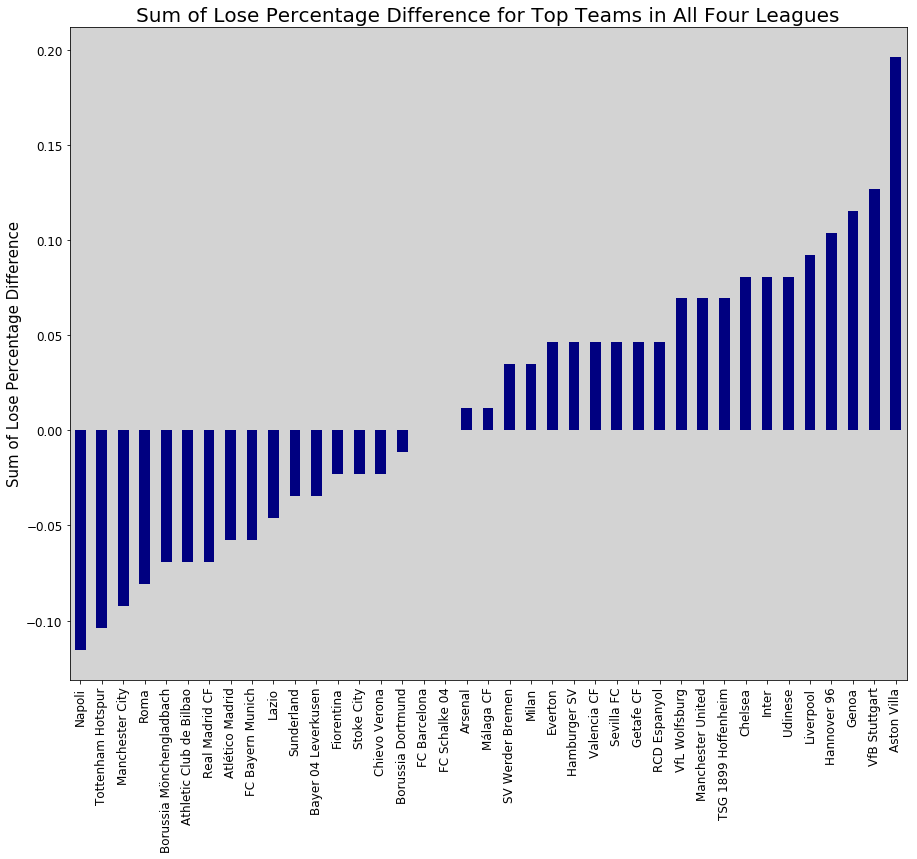

```python
ax = lose_sumdiff_all.plot(kind='bar',figsize=(15,12), colormap='jet')
plt.title('Sum of Lose Percentage Difference for Top Teams in All Four Leagues', fontsize= 20)
plt.xlabel(''); plt.ylabel('Sum of Lose Percentage Difference',fontsize=15)
plt.xticks(fontsize=12); plt.yticks(fontsize=12)
ax.set_facecolor('lightgrey')
```

# Question 1 Answer:

> The plot above represent thelose percentage sum of difference for each team. It goes from negative number to positive number. The negative number means the team improved from season to season. The improvement means that the lose percentage will decrease in each season resulting in negative number for the sum.  
> **Napoli from Italy shows the most improvement across all season followed by Tottenham Hotspur and Machester City from England.**

### What team attributes lead to the most victories?

> As I did in the previous section, I count the number of wins each team has for each season. Then, I calculate their winning percentage for each season.

```python
df_win = df_match.groupby('season')['win_team'].value_counts().reset_index(name = 'win_count')
df_win['win_percentage'] = df_win['win_count'] / sum(df_win['win_count']) * 100

df_win.head(10)
```

|  | season | win_team | win_count | win_percentage |
| --- | --- | --- | --- | --- |
| 0 | 2008/2009 | Manchester United | 28 | 0.323139 |
| 1 | 2008/2009 | FC Barcelona | 27 | 0.311598 |
| 2 | 2008/2009 | Chelsea | 25 | 0.288517 |
| 3 | 2008/2009 | Inter | 25 | 0.288517 |
| 4 | 2008/2009 | Liverpool | 25 | 0.288517 |
| 5 | 2008/2009 | Real Madrid CF | 25 | 0.288517 |
| 6 | 2008/2009 | Milan | 22 | 0.253895 |
| 7 | 2008/2009 | Fiorentina | 21 | 0.242354 |
| 8 | 2008/2009 | Juventus | 21 | 0.242354 |
| 9 | 2008/2009 | Sevilla FC | 21 | 0.242354 |

> I rename the "win_team" label to "team_name".

```python
df_win.rename(columns={'win_team': 'team_name'}, inplace=True)

df_win.head(10)
```

|  | season | team_name | win_count | win_percentage |
| --- | --- | --- | --- | --- |
| 0 | 2008/2009 | Manchester United | 28 | 0.323139 |
| 1 | 2008/2009 | FC Barcelona | 27 | 0.311598 |
| 2 | 2008/2009 | Chelsea | 25 | 0.288517 |
| 3 | 2008/2009 | Inter | 25 | 0.288517 |
| 4 | 2008/2009 | Liverpool | 25 | 0.288517 |
| 5 | 2008/2009 | Real Madrid CF | 25 | 0.288517 |
| 6 | 2008/2009 | Milan | 22 | 0.253895 |
| 7 | 2008/2009 | Fiorentina | 21 | 0.242354 |
| 8 | 2008/2009 | Juventus | 21 | 0.242354 |
| 9 | 2008/2009 | Sevilla FC | 21 | 0.242354 |

> I create a pivot table to make the winning percentage is easier to analyze.

```python
win_pivot = df_win.reset_index().pivot(index='season', columns = 'team_name', values='win_percentage')

win_pivot
```

| team_name season | 1. FC Kaiserslautern | 1. FC Köln | 1. FC Nürnberg | 1. FSV Mainz 05 | Arsenal | Aston Villa | Atalanta | Athletic Club de Bilbao | Atlético Madrid | Bari | ... | VfB Stuttgart | VfL Bochum | VfL Wolfsburg | Villarreal CF | Watford | West Bromwich Albion | West Ham United | Wigan Athletic | Wolverhampton Wanderers | Xerez Club Deportivo |
| --- | --- | --- | --- | --- | --- | --- | --- | --- | --- | --- | --- | --- | --- | --- | --- | --- | --- | --- | --- | --- | --- |
| 2008/2009 | NaN | 0.126947 | NaN | NaN | 0.230814 | 0.196192 | 0.150029 | 0.138488 | 0.230814 | NaN | ... | 0.219273 | 0.080785 | 0.242354 | 0.207732 | NaN | 0.092325 | 0.161570 | 0.138488 | NaN | NaN |
| 2009/2010 | NaN | 0.103866 | 0.092325 | 0.138488 | 0.265436 | 0.196192 | 0.103866 | 0.173110 | 0.150029 | 0.150029 | ... | 0.173110 | 0.069244 | 0.161570 | 0.184651 | NaN | NaN | 0.092325 | 0.103866 | 0.103866 | 0.092325 |
| 2010/2011 | 0.150029 | 0.150029 | 0.150029 | 0.207732 | 0.219273 | 0.138488 | NaN | 0.207732 | 0.196192 | 0.057703 | ... | 0.138488 | NaN | 0.103866 | 0.207732 | NaN | 0.138488 | 0.080785 | 0.103866 | 0.126947 | NaN |
| 2011/2012 | 0.046163 | 0.092325 | 0.138488 | 0.103866 | 0.242354 | 0.080785 | 0.150029 | 0.138488 | 0.173110 | NaN | ... | 0.173110 | NaN | 0.150029 | 0.103866 | NaN | 0.150029 | NaN | 0.126947 | 0.057703 | NaN |
| 2012/2013 | NaN | NaN | 0.126947 | 0.115407 | 0.242354 | 0.115407 | 0.126947 | 0.138488 | 0.265436 | NaN | ... | 0.138488 | NaN | 0.115407 | NaN | NaN | 0.161570 | 0.138488 | 0.103866 | NaN | NaN |
| 2013/2014 | NaN | NaN | 0.057703 | 0.184651 | 0.276976 | 0.115407 | 0.173110 | 0.230814 | 0.323139 | NaN | ... | 0.092325 | NaN | 0.207732 | 0.196192 | NaN | 0.080785 | 0.126947 | NaN | NaN | NaN |
| 2014/2015 | NaN | 0.103866 | NaN | 0.103866 | 0.253895 | 0.115407 | 0.080785 | 0.173110 | 0.265436 | NaN | ... | 0.103866 | NaN | 0.230814 | 0.184651 | NaN | 0.126947 | 0.138488 | NaN | NaN | NaN |
| 2015/2016 | NaN | 0.115407 | NaN | 0.161570 | 0.230814 | 0.034622 | 0.126947 | 0.207732 | 0.323139 | NaN | ... | 0.103866 | NaN | 0.138488 | 0.207732 | 0.138488 | 0.115407 | 0.184651 | NaN | NaN | NaN |

8 rows × 129 columns

> When we analyzed the lose percentage in question one, we saw null values because many of the teams did not play in all eight seasons. In this data table, we also experience the same problem. Consequently, I delete all the teams that do not appear in all seasons.

```python
win_pivot.dropna(axis=1,inplace=True)

win_pivot
```

| team_name season | Arsenal | Aston Villa | Athletic Club de Bilbao | Atlético Madrid | Bayer 04 Leverkusen | Borussia Dortmund | Borussia Mönchengladbach | Chelsea | Chievo Verona | Everton | ... | SV Werder Bremen | Sevilla FC | Stoke City | Sunderland | TSG 1899 Hoffenheim | Tottenham Hotspur | Udinese | Valencia CF | VfB Stuttgart | VfL Wolfsburg |
| --- | --- | --- | --- | --- | --- | --- | --- | --- | --- | --- | --- | --- | --- | --- | --- | --- | --- | --- | --- | --- | --- |
| 2008/2009 | 0.230814 | 0.196192 | 0.138488 | 0.230814 | 0.161570 | 0.173110 | 0.092325 | 0.288517 | 0.092325 | 0.196192 | ... | 0.138488 | 0.242354 | 0.138488 | 0.103866 | 0.173110 | 0.161570 | 0.184651 | 0.207732 | 0.219273 | 0.242354 |
| 2009/2010 | 0.265436 | 0.196192 | 0.173110 | 0.150029 | 0.173110 | 0.184651 | 0.115407 | 0.311598 | 0.138488 | 0.184651 | ... | 0.196192 | 0.219273 | 0.126947 | 0.126947 | 0.126947 | 0.242354 | 0.126947 | 0.242354 | 0.173110 | 0.161570 |
| 2010/2011 | 0.219273 | 0.138488 | 0.207732 | 0.196192 | 0.230814 | 0.265436 | 0.115407 | 0.242354 | 0.126947 | 0.150029 | ... | 0.115407 | 0.196192 | 0.150029 | 0.138488 | 0.126947 | 0.184651 | 0.230814 | 0.242354 | 0.138488 | 0.103866 |
| 2011/2012 | 0.242354 | 0.080785 | 0.138488 | 0.173110 | 0.173110 | 0.288517 | 0.196192 | 0.207732 | 0.126947 | 0.173110 | ... | 0.126947 | 0.150029 | 0.126947 | 0.126947 | 0.115407 | 0.230814 | 0.207732 | 0.196192 | 0.173110 | 0.150029 |
| 2012/2013 | 0.242354 | 0.115407 | 0.138488 | 0.265436 | 0.219273 | 0.219273 | 0.138488 | 0.253895 | 0.138488 | 0.184651 | ... | 0.092325 | 0.161570 | 0.103866 | 0.103866 | 0.092325 | 0.242354 | 0.207732 | 0.219273 | 0.138488 | 0.115407 |
| 2013/2014 | 0.276976 | 0.115407 | 0.230814 | 0.323139 | 0.219273 | 0.253895 | 0.184651 | 0.288517 | 0.115407 | 0.242354 | ... | 0.115407 | 0.207732 | 0.150029 | 0.115407 | 0.126947 | 0.242354 | 0.138488 | 0.150029 | 0.092325 | 0.207732 |
| 2014/2015 | 0.253895 | 0.115407 | 0.173110 | 0.265436 | 0.196192 | 0.150029 | 0.219273 | 0.300058 | 0.115407 | 0.138488 | ... | 0.126947 | 0.265436 | 0.173110 | 0.080785 | 0.138488 | 0.219273 | 0.115407 | 0.253895 | 0.103866 | 0.230814 |
| 2015/2016 | 0.230814 | 0.034622 | 0.207732 | 0.323139 | 0.207732 | 0.276976 | 0.196192 | 0.138488 | 0.150029 | 0.126947 | ... | 0.115407 | 0.161570 | 0.161570 | 0.103866 | 0.103866 | 0.219273 | 0.115407 | 0.126947 | 0.103866 | 0.138488 |

8 rows × 40 columns

> I average the winning percentage for these teams and sort them from highest to lowest.

```python
win_pivot_mean = win_pivot.mean().sort_values(ascending = False)

win_pivot_mean
```

```
team_name
FC Barcelona                0.337565
Real Madrid CF              0.328909
FC Bayern Munich            0.278419
Manchester United           0.276976
Juventus                    0.272649
Chelsea                     0.253895
Manchester City             0.252452
Arsenal                     0.245239
Atlético Madrid             0.240912
Roma                        0.233699
Borussia Dortmund           0.226486
Milan                       0.222158
Inter                       0.222158
Napoli                      0.220716
Tottenham Hotspur           0.217830
Liverpool                   0.216388
Valencia CF                 0.204847
Sevilla FC                  0.200519
Bayer 04 Leverkusen         0.197634
Fiorentina                  0.190421
Lazio                       0.188979
FC Schalke 04               0.183208
Athletic Club de Bilbao     0.175995
Everton                     0.174553
VfL Wolfsburg               0.168782
Udinese                     0.165897
Borussia Mönchengladbach    0.157242
Genoa                       0.152914
Málaga CF                   0.152914
VfB Stuttgart               0.142816
Stoke City                  0.141373
RCD Espanyol                0.139931
Getafe CF                   0.135603
Hamburger SV                0.134160
Hannover 96                 0.131275
SV Werder Bremen            0.128390
Chievo Verona               0.125505
TSG 1899 Hoffenheim         0.125505
Aston Villa                 0.124062
Sunderland                  0.112522
dtype: float64
```

> I present the win percentage average in a bar plot for analysis.

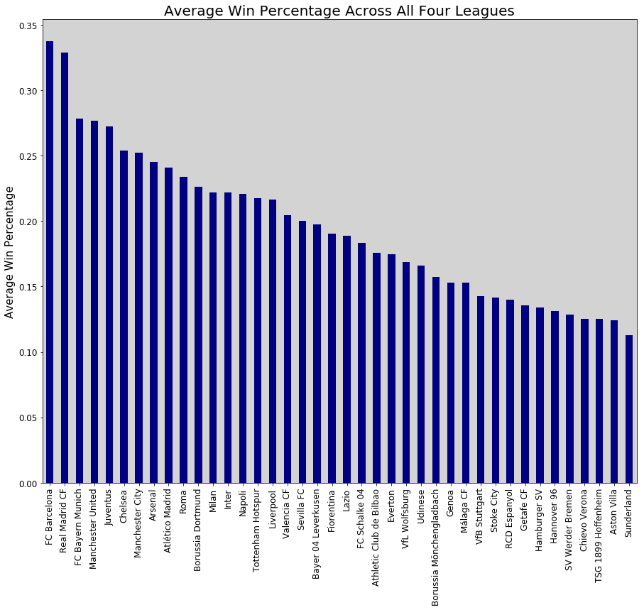

```python
ax = win_pivot_mean.plot(kind='bar', figsize=(15,12), colormap='jet')
plt.title('Average Win Percentage Across All Four Leagues', fontsize= 20)
plt.xlabel(''); plt.ylabel('Average Win Percentage', fontsize=15)
plt.xticks(fontsize=12); plt.yticks(fontsize=12)
ax.set_facecolor('lightgrey')
```

> **From the figure, it appears that FC Barcelona from Spain League has the highest winning percentage across all seasons.**  
> Furthermore, I take the top five teams based on result above and query their team attributes from the team attribute dataframe.

```python
topfive_team_att = df_team_att.query('team_name == "FC Barcelona" or team_name == "Real Madrid CF" or team_name == "FC Bayern Munich" or team_name == "Manchester United" or team_name == "Juventus"')

topfive_team_att.head()
```

|  | team_name | date | buildUpPlaySpeed | buildUpPlaySpeedClass | buildUpPlayDribblingClass | buildUpPlayPassing | buildUpPlayPassingClass | buildUpPlayPositioningClass | chanceCreationPassing | chanceCreationPassingClass | ... | chanceCreationShooting | chanceCreationShootingClass | chanceCreationPositioningClass | defencePressure | defencePressureClass | defenceAggression | defenceAggressionClass | defenceTeamWidth | defenceTeamWidthClass | defenceDefenderLineClass |
| --- | --- | --- | --- | --- | --- | --- | --- | --- | --- | --- | --- | --- | --- | --- | --- | --- | --- | --- | --- | --- | --- |
| 633 | Real Madrid CF | 2010-02-22 00:00:00 | 55 | Balanced | Little | 30 | Short | Free Form | 70 | Risky | ... | 70 | Lots | Free Form | 65 | Medium | 40 | Press | 65 | Normal | Offside Trap |
| 634 | Real Madrid CF | 2011-02-22 00:00:00 | 54 | Balanced | Little | 39 | Mixed | Free Form | 67 | Risky | ... | 67 | Lots | Free Form | 68 | High | 55 | Press | 55 | Normal | Cover |
| 635 | Real Madrid CF | 2012-02-22 00:00:00 | 45 | Balanced | Little | 35 | Mixed | Free Form | 71 | Risky | ... | 73 | Lots | Free Form | 49 | Medium | 60 | Press | 68 | Wide | Cover |
| 636 | Real Madrid CF | 2013-09-20 00:00:00 | 50 | Balanced | Little | 41 | Mixed | Organised | 68 | Risky | ... | 72 | Lots | Free Form | 39 | Medium | 49 | Press | 65 | Normal | Cover |
| 637 | Real Madrid CF | 2014-09-19 00:00:00 | 50 | Balanced | Normal | 41 | Mixed | Organised | 68 | Risky | ... | 69 | Lots | Free Form | 39 | Medium | 49 | Press | 65 | Normal | Cover |

5 rows × 22 columns

> In the table, each team has a couple of attribute data. I take the average of the team attributes and grouo it by the team name.

```python
top_att_mean = topfive_team_att.groupby('team_name').mean()

top_att_mean
```

| team_name | buildUpPlaySpeed | buildUpPlayPassing | chanceCreationPassing | chanceCreationCrossing | chanceCreationShooting | defencePressure | defenceAggression | defenceTeamWidth |
| --- | --- | --- | --- | --- | --- | --- | --- | --- |
| FC Barcelona | 35.833333 | 34.000000 | 45.166667 | 33.333333 | 53.000000 | 64.333333 | 54.500000 | 66.500000 |
| FC Bayern Munich | 48.666667 | 35.166667 | 38.500000 | 40.666667 | 49.666667 | 57.166667 | 48.833333 | 55.166667 |
| Juventus | 45.833333 | 32.833333 | 56.666667 | 60.500000 | 65.666667 | 44.000000 | 57.333333 | 41.166667 |
| Manchester United | 51.833333 | 45.833333 | 50.000000 | 63.166667 | 53.833333 | 45.000000 | 48.000000 | 54.833333 |
| Real Madrid CF | 50.666667 | 38.666667 | 67.500000 | 53.833333 | 69.000000 | 52.000000 | 52.166667 | 63.500000 |

> I plot the above table for easier analysis.

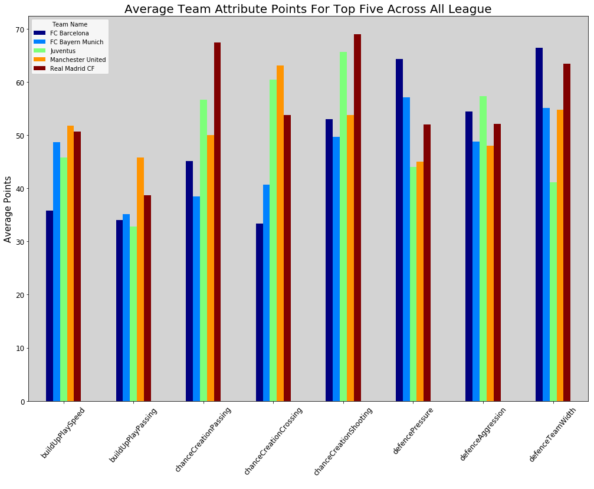

```python
ax = top_att_mean.T.plot(kind='bar',figsize=(17,12), colormap='jet')
plt.title('Average Team Attribute Points For Top Five Across All League', fontsize=20)
plt.xlabel(' '); plt.ylabel('Average Points', fontsize=15)
plt.xticks(fontsize=12, rotation = 50); plt.yticks(fontsize=12)
plt.legend(title='Team Name', fontsize= 10)
ax.set_facecolor('lightgrey')
```

# Question 2 Answer:

> The plot shows the attribute point for each catagory. The attributes seem to have little differences between the teams. The buildUpPlaySpeed for FC Barcelona is a lot less than the other winning teams which I find it interesting. In my opinion, buildUpPlaySpeed will determine the game tempo. FC Barcelona plays the game slower because they want to get higher ball possesion and eventually control the game. FC Barcelona also has higher defencePressure and defenceTeamWidth. I think the defence attributes are significant because they pressure the defence more than the other team and also cover the defence area wider in match. These makes it more difficult for the opponent to score a goal and lead to higher winning percentage than the other team.  
> **the team attributes that lead to the most victories (FC Barcelona) are:**  
> **BuidlUpPlay-Speed: 35.8**  
> **BuildUpPlay-Passing: 34.0**  
> **ChanceCreation-Passing: 45.2**  
> **ChanceCreation-Crossing: 33.3**  
> **ChanceCreation-shooting: 53.0**  
> **Defence-Pressure: 64.3**  
> **Defence-Aggression: 54.5**  
> **Defence-TeamWidth: 66.5**

> I also want to compare the top five team attributes to the bottom five. So, I create the same pivot table as previous for the bottom teams.

```python
botfive_team_att = df_team_att.query('team_name == "SV Werder Bremen" or team_name == "Chievo Verona" or team_name == "TSG 1899 Hoffenheim" or team_name == "Aston Villa" or team_name == "Sunderland"')

bot_att_mean = botfive_team_att.groupby('team_name').mean()

bot_att_mean.head()
```

| team_name | buildUpPlaySpeed | buildUpPlayPassing | chanceCreationPassing | chanceCreationCrossing | chanceCreationShooting | defencePressure | defenceAggression | defenceTeamWidth |
| --- | --- | --- | --- | --- | --- | --- | --- | --- |
| Aston Villa | 65.666667 | 58.666667 | 54.833333 | 56.000000 | 47.333333 | 36.833333 | 48.666667 | 51.166667 |
| Chievo Verona | 58.000000 | 57.666667 | 48.333333 | 53.833333 | 55.833333 | 34.833333 | 60.333333 | 53.166667 |
| SV Werder Bremen | 58.666667 | 43.833333 | 63.166667 | 53.166667 | 61.500000 | 57.666667 | 51.666667 | 64.166667 |
| Sunderland | 57.000000 | 60.833333 | 56.666667 | 55.333333 | 59.000000 | 43.666667 | 52.166667 | 51.833333 |
| TSG 1899 Hoffenheim | 62.500000 | 47.833333 | 59.000000 | 55.000000 | 59.166667 | 57.666667 | 58.166667 | 49.000000 |

> Then, I create a new column for each table that indicates which one is top team and bottom team. Finally, I combine both pivot table and take the average for each team group.

```python
top_array = ['top_team']*5 ; bot_array = ['bottom_team']*5

top_att_mean['group'] = top_array ; bot_att_mean['group'] = bot_array

top_bot = top_att_mean.append(bot_att_mean)

mean_comparison = top_bot.groupby('group').mean()
```

> I plot the comparison in bar chart.

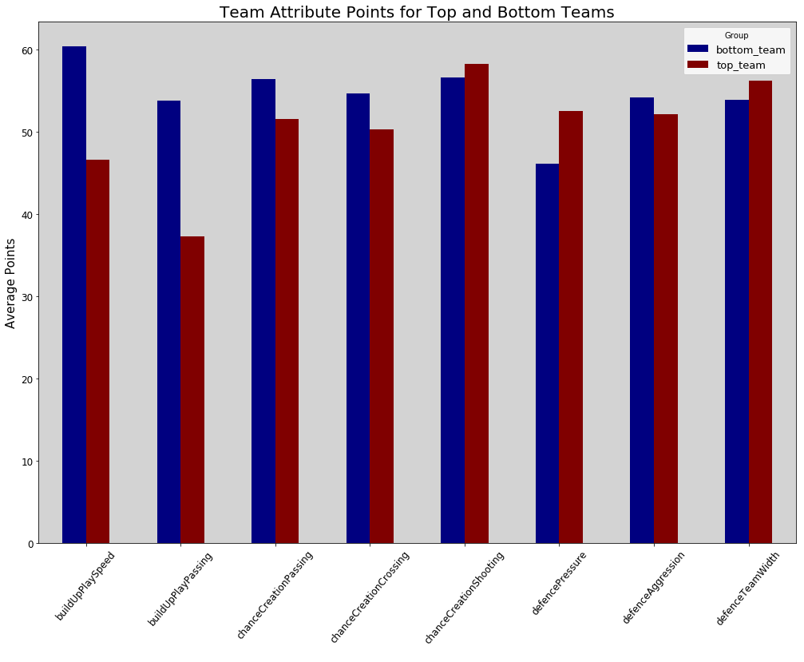

```python
ax = mean_comparison.T.plot(kind='bar',figsize=(17,12), colormap='jet')
plt.title('Team Attribute Points for Top and Bottom Teams', fontsize=20)
plt.xlabel(' '); plt.ylabel('Average Points', fontsize=15)
plt.xticks(fontsize=12, rotation = 50); plt.yticks(fontsize=12)
plt.legend(title='Group', fontsize= 13)
ax.set_facecolor('lightgrey')
```

> **The buildUpPlaySpeed for the top team is lower compared to the bottom team. As we disscused before, the play speed determine the game tempo. The top team indeed control the game more than the bottom team as they have higher ball possesion. The buildUpPlayPassing for the top team is lower than the bottom team. The other categories do not seem have much of a difference in comparison.**

### Does older player has higher overall rating than younger player?

> To answer the question, I create a function that change the data type for "date" table to datetime object and use it to find the player age. The recent date that I use is 2016-01-01 because the match data goes until year of 2016.

```python
def get_age(x):
    date = x.split(" ")[0]
    born = dt.datetime.strptime(date, "%Y-%m-%d").date()
    recent_date = dt.datetime.strptime("2016-01-01", "%Y-%m-%d").date()
    return recent_date.year - born.year - ((recent_date.month, recent_date.day) < (born.month, born.day))

df_player_att['age'] = df_player_att['birthday'].apply(lambda x:get_age(x))
```

> The player attribute dataframe shows that each player has more than one data. So, I take the average of the data for each player.

```python
df_player_att = df_player_att.groupby('player_name').mean().round()
```

> Then, I plot the histogram for the age to see the distribution.

```
Text(0.5,0,'Age')
```

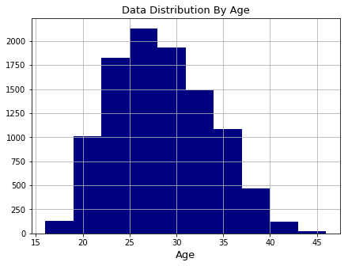

```python
df_player_att['age'].hist(figsize=(7,5), color='navy')
plt.title('Data Distribution By Age', fontsize=13)
plt.xlabel('Age', fontsize=13)
```

> The distribution is skewed to the right and we can see that there are some outliers in the dataset. So, I make a boxplot to see which are the outliers.

```
Text(0,0.5,'Age')
```

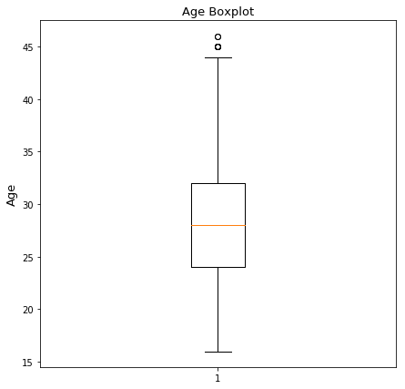

```python
plt.figure(figsize=(7,7))
plt.boxplot(df_player_att['age'])
plt.title('Age Boxplot', fontsize=13)
plt.ylabel('Age',fontsize=13)
```

> The boxplot shows most of the data concentrated between age 24 to 32. Then, I query the dataframe to drop the age outside the boxplot.

```python
new_df_player_att = df_player_att.query('age >=24 and age <= 32')
```

> I find the "overall rating" column statistic using the code below.

```python
new_df_player_att['overall_rating'].describe()
```

```
count    5817.000000
mean       67.318033
std         5.809677
min        44.000000
25%        64.000000
50%        67.000000
75%        71.000000
max        92.000000
Name: overall_rating, dtype: float64
```

> Next, I categorize the overall rating to three groups: low, medium, and high, based on the given statistic. Then, I assign the category using this function.

```python
def get_rating_class(x):
    if x <= 64:
        return 'low'
    elif x >= 64 and x <= 71:
        return 'mid'
    else:
        return 'high'

new_df_player_att['rating_class'] = new_df_player_att['overall_rating'].apply(lambda x:get_rating_class(x))
```

> I create three separate table based on the categories for easier analysis.

```python
low = new_df_player_att.query('rating_class == "low"')
mid = new_df_player_att.query('rating_class == "mid"')
high = new_df_player_att.query('rating_class == "high"')
```

> Finally, I find the average age for each category and plot it into a bar chart.

```python
low_age_mean = low['age'].mean()
mid_age_mean = mid['age'].mean()
high_age_mean = high['age'].mean()
```

```
Text(0,0.5,'Average Age')
```

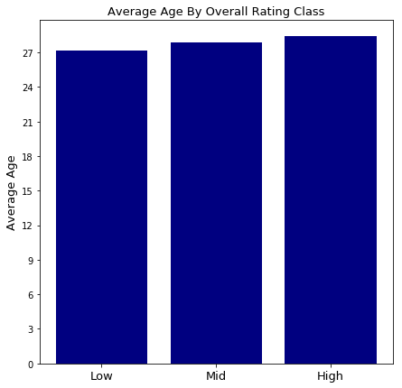

```python
x = [1, 2, 3]
y = [low_age_mean, mid_age_mean, high_age_mean]

plt.figure(figsize=(7,7))
plt.bar(x, y, color='navy')
plt.title('Average Age By Overall Rating Class',fontsize=13)
plt.xticks((1,2,3),('Low','Mid','High'), fontsize=13)
plt.yticks(np.arange(0, 30, step=3))
plt.ylabel('Average Age',fontsize=13)
```

# Question 3 Answer:

> **The result shows that as the overall rating class increase, the age is also increasing. It confirms that older player has higher overall rating. I think it is because at older age, the player has more experience and also better skills, thus their overall rating are higher.**

## Conclusions

> Based on the analysis, we find that Napoli has the best improvement compared to other teams as they lower their lose percentage in each season. We also find FC Barcelona has the highest winning percentage across all seasons. Then, we discuss how buildUpPlaySpeed for the top five teams is much lower than the other. It shows that the winning teams control the game more and their scoring chance is higher. Finally, we confirm that older player has higher overall rating due to more experience and skill at older age.  
> There are some limitations that I discovered while I was doing this project. In question one, it would be better to graph the plot with different color to show which country is the team from. It would be easy for us to understand the plot especially if the audience is unfamiliar with european soccer. In question two, the comparison for team attribute is not enough to draw a conclusion about winning percentage. It would be better if we can join the player attribute with the team for better understanding. The winning teams have some of the best players in the league and it definitely affects their chance to win.  
> In the future, we can use this dataset to explore other things such as a soccer match prediction model.

# Sources

> https://www.kaggle.com/hugomathien/soccer  
> https://stackoverflow.com/  
> https://www.udacity.com/